# Measurement models

```r
library(ctsem)
library(ggplot2)
```

A ctsem model has two parts. The **dynamic** part describes how the latent processes change between observations, and the **measurement** part describes how an observation relates to the latent state at that time. This vignette is about the measurement part: how many indicators load on a process, what kind of variable each indicator is, how to combine kinds, and what to do when a loading or a residual variance is not constant.

Everything here uses `backend = 'julia'`. The ordinal, count and censored types are only available there, and the two backends handle binary indicators differently, so all the examples use the same backend.

# The measurement equation

At each observed time point the filter has a predicted latent state $\eta$. For every manifest variable $j$ observed at that time, ctsem forms a linear predictor

$$\mu_j \;=\; \text{MANIFESTMEANS}_j \;+\; \text{LAMBDA}_{j\cdot}\, \eta$$

and then applies the observation model set by that variable’s `manifesttype`:

| `manifesttype` | Variable | Observation model | Residual |
| --- | --- | --- | --- |
| `0` | continuous | $y_j \sim N(\mu_j,\ \text{MANIFESTVAR})$ | free |
| `1` | binary, coded 0/1 | $P(y_j = 1) = \text{logit}^{-1}(\mu_j)$ | none |
| `2` | ordinal, coded $1..K$ | $P(y_j \le k) = \text{logit}^{-1}(\tau_{jk} - \mu_j)$ | none |
| `3` | count, non-negative integers | $y_j \sim \text{Poisson}(e^{\mu_j + e_j})$, $e_j \sim N(0, \text{MANIFESTVAR})$ | free |
| `4` | censored | $N(\mu_j,\ \text{MANIFESTVAR})$, observed only inside $[\,c^-_j, c^+_j\,]$ | free |

Four things follow from that table.

**Binary and ordinal indicators have no residual variance.** Their randomness comes from the link function. A residual term added to the linear predictor would not be identified: under a probit link $E_e\,\Phi(\mu_j + e) = \Phi(\mu_j / \sqrt{1 + v})$ exactly, so such a term is absorbed into the loadings and thresholds, and under the logistic link the same holds approximately. Their rows and columns of `MANIFESTVAR` are fixed to zero, and `ctFit()` fixes any that were left free.

**The other three types have a residual, with a different meaning in each.** For a continuous indicator it is the usual measurement error variance. For a censored indicator it is the variance of the Gaussian that is observed only inside the limits. For a count it is a *dispersion*, a Gaussian term added to the log rate, which makes the observation Poisson-lognormal. A Poisson’s variance equals its mean, which is why the dispersion is identified. It shifts the mean by $v/2$, which `MANIFESTMEANS` absorbs, and multiplies the variance by a factor nothing else in the model can produce. It is the only parameter in a ctsem model that changes a count’s variance-to-mean ratio. If it is left out, `DIFFUSION` absorbs any overdispersion, and `DIFFUSION` is usually a parameter of interest. For counts and censored indicators only the diagonal is used. Each is scored on its own, so it cannot have correlated measurement error, and `ctFit()` stops with an error if an off-diagonal entry is not zero.

**The scale of the latent process has to be fixed somewhere.** With a Gaussian indicator you can fix a loading or fix `DIFFUSION`. With only binary or ordinal indicators there is no residual variance to trade against, so a loading and the process scale describe the same quantity. Fix the loadings and let `DIFFUSION` carry the scale.

**Location works the same way.** `CINT` and `T0MEANS` set the level of the process, and each indicator’s `MANIFESTMEANS` sets the level of that indicator relative to it. By default ctsem fixes `CINT` and `T0MEANS` to zero and frees `MANIFESTMEANS`, and the examples below, ordinal ones included, do the same. An ordinal indicator’s thresholds are also locations, so one of them is redundant: adding a constant to $\mu_j$ and to every $\tau_{jk}$ leaves the cumulative logit unchanged. ctsem fixes $\tau_{j1}$ at zero, so the location of an ordinal indicator is in its `MANIFESTMEANS`, as for other indicators, and `THRESHOLDS` estimates the K-2 gaps between successive thresholds. This lets `MANIFESTMEANS` be `indvarying`, so that one random effect shifts all of an indicator’s category boundaries together, which is what a person answering higher in general means. A random effect on the thresholds would need one effect for each boundary.

# One indicator or many

A univariate Ornstein-Uhlenbeck process, measured by three indicators at each occasion with loadings 1, 0.8 and 1.2:

```r
set.seed(3)
genmulti <- ctModel(type = 'ct', n.latent = 1, n.manifest = 3,
  manifestNames = c('y1', 'y2', 'y3'), latentNames = 'eta1',
  LAMBDA = matrix(c(1, 0.8, 1.2), 3, 1),
  DRIFT = matrix(-0.4), DIFFUSION = matrix(1.5), T0VAR = matrix(1.7),
  T0MEANS = matrix(0), CINT = matrix(0),
  MANIFESTMEANS = matrix(c(0, 0.5, -0.5), 3, 1),
  MANIFESTVAR = diag(0.8, 3), Tpoints = 10)

dmulti <- data.frame(ctGenerate(genmulti, n = 50, Tpoints = 10,
  backend = 'julia'))
head(dmulti, 3)
```

```
#>   id time        y1         y2        y3
#> 1  1    0 -3.347169 -1.8190194 -2.395708
#> 2  1    1 -1.309557 -0.5163224 -2.078168
#> 3  1    2 -1.175804  0.1784173 -1.663167
```

## A single indicator

With one indicator per process the loading cannot be estimated, and is fixed, by convention to 1. The measurement error can still be estimated. In a continuous time model, measurement error and process noise have different effects across time intervals, so `MANIFESTVAR` and `DIFFUSION` are separately identified.

```r
msingle <- ctModel(type = 'ct', n.latent = 1, n.manifest = 1,
  manifestNames = 'y1', latentNames = 'eta1', LAMBDA = matrix(1),
  CINT = matrix(0), T0MEANS = matrix(0))
msingle$pars$indvarying <- FALSE

fsingle <- ctFit(dmulti, msingle, backend = 'julia', cores = 2)
summary(fsingle)$popmeans
```

```
#>              mean    sd   2.5%    50%  97.5%   mode
#> drift_eta1 -0.331 0.095 -0.548 -0.317 -0.183 -0.316
#> diff_eta1   1.351 0.226  0.955  1.333  1.830  1.329
#> mvary1      0.973 0.138  0.732  0.960  1.271  0.969
#> mm_y1       0.056 0.163 -0.255  0.060  0.379  0.060
#> T0var_eta1  1.669 0.240  1.237  1.656  2.196  1.645
```

## Three indicators

Freeing the other two loadings, with the first fixed at 1, makes `eta1` a common factor. The latent process then has the scale of the first indicator:

```r
mmulti <- ctModel(type = 'ct', n.latent = 1, n.manifest = 3,
  manifestNames = c('y1', 'y2', 'y3'), latentNames = 'eta1',
  LAMBDA = matrix(c(1, 'lambda_y2', 'lambda_y3'), 3, 1),
  CINT = matrix(0), T0MEANS = matrix(0))
mmulti$pars$indvarying <- FALSE

fmulti <- ctFit(dmulti, mmulti, backend = 'julia', cores = 2)
summary(fmulti)$popmeans
```

```
#>              mean    sd   2.5%    50%  97.5%   mode
#> lambda_y2   0.795 0.027  0.741  0.794  0.847  0.794
#> lambda_y3   1.193 0.035  1.131  1.192  1.262  1.192
#> drift_eta1 -0.417 0.061 -0.553 -0.413 -0.310 -0.410
#> diff_eta1   1.592 0.082  1.443  1.590  1.762  1.592
#> mvary1      0.799 0.037  0.728  0.798  0.872  0.798
#> mvary2      0.785 0.032  0.725  0.785  0.849  0.783
#> mvary3      0.755 0.046  0.669  0.754  0.851  0.755
#> mm_y1       0.069 0.155 -0.225  0.066  0.364  0.068
#> mm_y2       0.615 0.125  0.369  0.612  0.856  0.614
#> mm_y3      -0.419 0.184 -0.764 -0.416 -0.066 -0.418
#> T0var_eta1  1.752 0.193  1.391  1.749  2.137  1.749
```

The loadings come back near their generating values, and the dynamic parameters are estimated more precisely than from one indicator:

```r
s1 <- summary(fsingle)$popmeans
s3 <- summary(fmulti)$popmeans
pars <- c('drift_eta1', 'diff_eta1')
data.frame(
  parameter = pars,
  truth = c(-0.4, 1.5),
  single = s1[pars, 'mean'], single_se = s1[pars, 'sd'],
  three = s3[pars, 'mean'], three_se = s3[pars, 'sd'],
  row.names = NULL)
```

```
#>    parameter truth single single_se  three three_se
#> 1 drift_eta1  -0.4 -0.331     0.095 -0.417    0.061
#> 2  diff_eta1   1.5  1.351     0.226  1.592    0.082
```

> **Fixing the scale, and starting values**

> Fixing `LAMBDA[1,1]` is one way to set the scale. Fixing `DIFFUSION` to 1 and freeing all three loadings fits the same model, and reports the loadings on the scale of the process instead of the scale of `y1`.

> The two are equivalent in principle, but the optimiser can end in different places. By default `ctFit` takes starting values for the variance parameters from the data (`optimcontrol$datastart`). This avoids a local optimum in which the latent variance collapses to zero, all of the signal is treated as measurement error, and the loadings run off to large values. Some models still lie near the boundary between two optima, where the small random variation ctsem adds to the starting values decides which one the fit reaches. If a fit reports non-convergence, or gives implausible loadings, run it again, and compare with `DIFFUSION`-anchored scaling or with explicit `inits`.

# The five indicator types

To see each type on its own, the next example generates one latent trajectory and measures it in five ways. The process is generated with a near-zero measurement variance, so that its single manifest variable is the latent state, from which the indicators below are built:

```r
set.seed(5)
nsub <- 80; nobs <- 10
process <- ctModel(type = 'ct', n.latent = 1, n.manifest = 1,
  manifestNames = 'eta', latentNames = 'eta1', LAMBDA = matrix(1),
  DRIFT = matrix(-0.4), DIFFUSION = matrix(1), T0VAR = matrix(1.12),
  T0MEANS = matrix(0), CINT = matrix(0), MANIFESTMEANS = matrix(0),
  MANIFESTVAR = matrix(1e-6), Tpoints = nobs)

d <- data.frame(ctGenerate(process, n = nsub, Tpoints = nobs,
  backend = 'r'))
eta <- d$eta
```

Two indicators of each kind, built by applying each row of the table above by hand, so that the link in the simulation is the one in the model:

```r
invlogit <- function(x) 1 / (1 + exp(-x))
ordinaldraw <- function(mu, tau) {          # cumulative logit
  cum <- sapply(tau, function(k) invlogit(k - mu))
  p <- cbind(cum, 1)
  p <- cbind(p[, 1, drop = FALSE], t(apply(p, 1, diff)))
  apply(p, 1, function(pr) sample.int(length(pr), 1, prob = pmax(pr, 0)))
}
tau <- c(-1, 0, 1)                          # four categories

d$y1 <- 0.0 + eta + rnorm(nrow(d), 0, 0.6)              # 0 continuous
d$y2 <- 0.5 + eta + rnorm(nrow(d), 0, 0.6)
d$b1 <- rbinom(nrow(d), 1, invlogit(-0.4 + eta))        # 1 binary
d$b2 <- rbinom(nrow(d), 1, invlogit( 0.4 + eta))
d$o1 <- ordinaldraw(eta, tau)                           # 2 ordinal
d$o2 <- ordinaldraw(eta, tau)
disp <- 0.3                                 # count dispersion, on the log rate
d$c1 <- rpois(nrow(d),                                  # 3 count
  exp(1.4 + 0.5 * eta + rnorm(nrow(d), 0, disp)))
d$c2 <- rpois(nrow(d), exp(1.2 + 0.5 * eta + rnorm(nrow(d), 0, disp)))
d$x1 <- pmin(pmax(2.0 + eta + rnorm(nrow(d), 0, 0.5), 0), 4)   # 4 censored
d$x2 <- pmin(pmax(1.8 + eta + rnorm(nrow(d), 0, 0.5), 0), 4)

d$eta <- NULL
head(d, 3)
```

```
#>   id time           y1          y2 b1 b2 o1 o2 c1 c2        x1        x2
#> 1  1    0 -1.426062341  0.59163773  0  0  2  3  4  1 0.6966535 0.5905002
#> 2  1    1  1.752632464  0.03085567  1  1  2  4  5  3 2.3802010 1.5137950
#> 3  1    2  0.006634949 -0.84232851  1  0  2  4  1  5 0.9411608 1.0590349
```

One subject, seen through all five instruments at once:

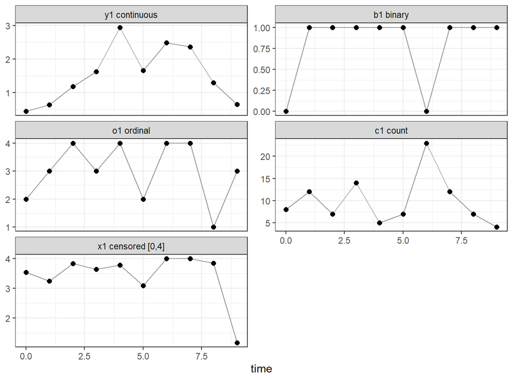

```r
shown <- c('y1', 'b1', 'o1', 'c1', 'x1')
long <- do.call(rbind, lapply(shown, function(v)
  data.frame(time = d$time[d$id == 2], value = d[[v]][d$id == 2],
    indicator = v)))
long$indicator <- factor(long$indicator, levels = shown,
  labels = c('y1 continuous', 'b1 binary', 'o1 ordinal', 'c1 count',
    'x1 censored [0,4]'))

ggplot(long, aes(time, value)) +
  geom_line(colour = 'grey60') + geom_point(size = 2) +
  facet_wrap(~indicator, scales = 'free_y', ncol = 2) +
  theme_bw() + labs(x = 'time', y = NULL)
```

## Specifying each type

`manifesttype` is a vector with one entry per manifest variable. Two of the types need further information, because `ctModel()` does not see the data:

- **ordinal** needs `ncategories`, so that the right number of thresholds can be created. `ctGenerate()` needs it too.
- **censored** needs `censormin` and `censormax`. These are known constants, the floor and ceiling of the instrument, which the data cannot estimate. For a variable censored on one side only, leave the other limit infinite.

A helper function, since the five models below differ only in their columns:

```r
buildmodel <- function(names, type, lambda = 1, ncat = 0,
  cmin = -Inf, cmax = Inf) {
  n <- length(names)
  # binary and ordinal are the two types with no residual of any kind
  mvar <- diag(0, n)
  if (type %in% c(0, 3, 4)) diag(mvar) <- paste0('mvar_', names)
  m <- ctModel(type = 'ct', n.latent = 1, n.manifest = n,
    manifestNames = names, latentNames = 'eta1',
    manifesttype = rep(type, n), ncategories = rep(ncat, n),
    censormin = rep(cmin, n), censormax = rep(cmax, n),
    LAMBDA = matrix(lambda, n, 1),
    MANIFESTMEANS = matrix(paste0('mm_', names), n, 1), MANIFESTVAR = mvar,
    CINT = matrix(0), T0MEANS = matrix(0))
  m$pars$indvarying <- FALSE
  m
}

models <- list(
  continuous = buildmodel(c('y1', 'y2'), 0),
  binary     = buildmodel(c('b1', 'b2'), 1),
  ordinal    = buildmodel(c('o1', 'o2'), 2, ncat = 4),
  count      = buildmodel(c('c1', 'c2'), 3, lambda = 0.5),
  censored   = buildmodel(c('x1', 'x2'), 4, cmin = 0, cmax = 4))
```

All of these models fix their loadings, so that the latent scale is set the same way in all five and the dynamic estimates below can be compared directly.

The count loadings are fixed at 0.5. A count’s loading sets how far its *log* rate moves as the process moves, and the exponential turns a wide latent range into a very skewed observation. The filter uses a Gaussian approximation to the state, which works well for a Poisson update only while the rate stays in a moderate range. With a loading of 1 on this process the log rates span about seven units (rates from 0.05 to 50), and in simulations `DRIFT` and `DIFFUSION` were then clearly underestimated. Halving the loading halves the range of the log rate, and the count estimates below are as accurate as the others. If your counts vary over orders of magnitude, treat their dynamic estimates with caution.

The count models also estimate a `MANIFESTVAR` diagonal, which for a count is the dispersion on the log rate, making the observation Poisson-lognormal. The counts above were generated with a dispersion of 0.3. It is worth freeing for real counts, because otherwise `DIFFUSION` absorbs any overdispersion.

## The same process, through five instruments

```r
fits <- lapply(models, function(m) ctFit(d, m, backend = 'julia', cores = 2))

pull <- function(f, p, what) summary(f)$popmeans[p, what]
data.frame(
  type = names(fits),
  drift = sapply(fits, pull, 'drift_eta1', 'mean'),
  drift_se = sapply(fits, pull, 'drift_eta1', 'sd'),
  diffusion = sapply(fits, pull, 'diff_eta1', 'mean'),
  diffusion_se = sapply(fits, pull, 'diff_eta1', 'sd'),
  row.names = NULL)
```

```
#>         type  drift drift_se diffusion diffusion_se
#> 1 continuous -0.444    0.052     1.054        0.049
#> 2     binary -0.287    0.117     0.694        0.222
#> 3    ordinal -0.345    0.109     0.890        0.187
#> 4      count -0.356    0.061     0.966        0.082
#> 5   censored -0.436    0.051     1.048        0.045
```

Every row of the table estimates the same two generating values, $-0.4$ and $1$, from the same latent trajectory, and every row is within one and a half standard errors of them. The instruments differ in how much information about the trajectory they carry, which shows in the standard errors. Two binary items per occasion carry little information about a continuous state, and their standard errors are about twice as large, while the continuous, censored and count pairs each estimate `DRIFT` with a standard error of 0.05 to 0.06.

The parameters specific to each type are in the same summary. An ordinal indicator’s location is in `MANIFESTMEANS`. `THRESHOLDS` holds the first threshold, fixed at zero and not reported, and then the **gap** to each later threshold, which keeps them in order. A four category variable therefore has one mean and two gaps:

```r
thr <- summary(fits$ordinal)$popmeans
gaps <- grep('threshold_o1', rownames(thr), value = TRUE)
thr[c('mm_o1', gaps), c('mean', 'sd')]
```

```
#>                 mean    sd
#> mm_o1          0.939 0.117
#> threshold_o1_2 0.997 0.079
#> threshold_o1_3 0.950 0.077
```

```r
# cumulate the gaps from the pinned zero, then subtract the mean, to read the
# thresholds on the latent scale
cumsum(c(0, thr[gaps, 'mean'])) - thr['mm_o1', 'mean']     # against c(-1, 0, 1)
```

```
#> [1] -0.939  0.058  1.008
```

A censored indicator’s residual standard deviation has its usual meaning. The model estimates it from the uncensored part of the scale, and treats a value at a limit as the probability of being at or beyond that limit:

```r
summary(fits$censored)$popmeans[c('mvar_x1', 'mvar_x2', 'mm_x1', 'mm_x2'),
  c('mean', 'sd')]
```

```
#>          mean    sd
#> mvar_x1 0.486 0.027
#> mvar_x2 0.501 0.026
#> mm_x1   2.080 0.074
#> mm_x2   1.901 0.076
```

```r
mean(d$x1 %in% c(0, 4))     # proportion of x1 observations at a limit
```

```
#> [1] 0.10375
```

# Combining types

## Several types on one latent

Indicators of different types can load on the same process. Each contributes its own likelihood term for the same predicted state, and the filter’s update at that time uses all of them:

```r
mixednames <- c('y1', 'b1', 'o1', 'c1', 'x1')
mvar <- diag(0, 5)
mvar[1, 1] <- 'mvar_y1'      # measurement error
mvar[4, 4] <- 'mvar_c1'      # the count's dispersion
mvar[5, 5] <- 'mvar_x1'      # the scale inside the censoring limits

mmixed <- ctModel(type = 'ct', n.latent = 1, n.manifest = 5,
  manifestNames = mixednames, latentNames = 'eta1',
  manifesttype = c(0, 1, 2, 3, 4),
  ncategories   = c(0, 0, 4, 0, 0),
  censormin     = c(-Inf, -Inf, -Inf, -Inf, 0),
  censormax     = c( Inf,  Inf,  Inf,  Inf, 4),
  LAMBDA = matrix(c(1, 1, 1, 0.5, 1), 5, 1),   # the count as generated
  MANIFESTMEANS = matrix(paste0('mm_', mixednames), 5, 1),
  MANIFESTVAR = mvar, CINT = matrix(0), T0MEANS = matrix(0))
mmixed$pars$indvarying <- FALSE

fmixed <- ctFit(d, mmixed, backend = 'julia', cores = 2)
summary(fmixed)$popmeans
```

```
#>                  mean    sd   2.5%    50%  97.5%   mode
#> drift_eta1     -0.450 0.049 -0.553 -0.446 -0.360 -0.449
#> diff_eta1       1.034 0.046  0.948  1.031  1.122  1.035
#> mvar_y1         0.622 0.022  0.578  0.622  0.665  0.621
#> mvar_c1         0.319 0.028  0.268  0.318  0.377  0.319
#> mvar_x1         0.496 0.024  0.451  0.496  0.542  0.495
#> mm_y1           0.129 0.079 -0.024  0.130  0.286  0.128
#> mm_b1          -0.223 0.111 -0.443 -0.223 -0.014 -0.222
#> mm_o1           0.942 0.110  0.715  0.943  1.163  0.945
#> mm_c1           1.462 0.043  1.375  1.463  1.546  1.462
#> mm_x1           2.082 0.078  1.928  2.083  2.240  2.082
#> T0var_eta1      1.174 0.098  0.995  1.170  1.368  1.175
#> threshold_o1_2  1.006 0.074  0.862  1.003  1.158  1.004
#> threshold_o1_3  0.952 0.072  0.820  0.947  1.098  0.952
```

One indicator of each kind estimates the process about as precisely as the best pair of one kind above, and about twice as precisely as the binary or ordinal pairs, with the thresholds, the three `MANIFESTVAR` entries and five intercepts estimated as well. It is worth using all the indicators you have, whatever their kind.

## Several types on different latents

More often, different types measure different things. An ordinal questionnaire item and a binary event indicator might measure one construct, and a count, a censored scale score and a continuous variable another, with the question being how the two constructs affect each other. That is a two-process model with a block structured `LAMBDA`.

```r
set.seed(11)
twonames <- c('o1', 'b1', 'c1', 'x1', 'y1')
lambda2 <- matrix(0, 5, 2)
lambda2[1:2, 1] <- 1     # ordinal and binary measure eta1
lambda2[3:5, 2] <- 1     # count, censored and continuous measure eta2

genvar <- diag(0, 5)
genvar[3, 3] <- 0.3      # the count's dispersion, on its log rate
genvar[4, 4] <- 0.4
genvar[5, 5] <- 0.6
gen2 <- ctModel(type = 'ct', n.latent = 2, n.manifest = 5,
  manifestNames = twonames, latentNames = c('eta1', 'eta2'),
  manifesttype = c(2, 1, 3, 4, 0), ncategories = c(4, 0, 0, 0, 0),
  censormin = c(-Inf, -Inf, -Inf, 0, -Inf),
  censormax = c(Inf, Inf, Inf, 4, Inf),
  LAMBDA = lambda2,
  DRIFT = matrix(c(-0.4, 0.25, -0.15, -0.7), 2, 2, byrow = TRUE),
  DIFFUSION = diag(0.8, 2), T0VAR = diag(1, 2), T0MEANS = matrix(0, 2, 1),
  CINT = matrix(0, 2, 1),
  MANIFESTMEANS = matrix(c(1, -0.4, 0.5, 2.0, 0.3), 5, 1),
  MANIFESTVAR = genvar, Tpoints = 10)

# The first threshold is pinned at zero and the rest are gaps, so thresholds of
# -1, 0 and 1 are a manifest mean of 1 with both gaps at 1.
gen2$pars$value[gen2$pars$matrix %in% 'THRESHOLDS' & gen2$pars$col > 1] <- 1

d2 <- data.frame(ctGenerate(gen2, n = 60, Tpoints = 10,
  backend = 'julia'))
head(d2, 3)
```

```
#>   id time o1 b1 c1       x1         y1
#> 1  1    0  1  0  7 2.183019  0.5605175
#> 2  1    1  1  0  1 1.688552 -1.3622011
#> 3  1    2  2  0  1 1.867846  0.3068517
```

`ctGenerate(backend = 'julia')` simulates the latent process and draws each observation from its measurement model given the state, applying the links above. The R generator simulates a linear Gaussian system without links, and warns if asked to generate from a model with non-Gaussian indicators.

The estimation model has the same block structure, with the measurement parameters free:

```r
estvar <- diag(0, 5)
estvar[3, 3] <- 'mvar_c1'
estvar[4, 4] <- 'mvar_x1'
estvar[5, 5] <- 'mvar_y1'

m2 <- ctModel(type = 'ct', n.latent = 2, n.manifest = 5,
  manifestNames = twonames, latentNames = c('eta1', 'eta2'),
  manifesttype = c(2, 1, 3, 4, 0), ncategories = c(4, 0, 0, 0, 0),
  censormin = c(-Inf, -Inf, -Inf, 0, -Inf),
  censormax = c(Inf, Inf, Inf, 4, Inf),
  LAMBDA = lambda2,
  MANIFESTMEANS = matrix(paste0('mm_', twonames), 5, 1),
  MANIFESTVAR = estvar, CINT = matrix(0, 2, 1), T0MEANS = matrix(0, 2, 1))
m2$pars$indvarying <- FALSE

f2 <- ctFit(d2, m2, backend = 'julia', cores = 2)
summary(f2)$popmeans
```

```
#>                   mean    sd   2.5%    50%  97.5%   mode
#> drift_eta1      -0.372 0.138 -0.714 -0.350 -0.163 -0.350
#> drift_eta1_eta2  0.441 0.144  0.166  0.441  0.718  0.443
#> drift_eta2_eta1 -0.176 0.065 -0.303 -0.178 -0.049 -0.177
#> drift_eta2      -0.644 0.085 -0.826 -0.634 -0.496 -0.639
#> diff_eta1        0.893 0.229  0.529  0.874  1.403  0.865
#> diff_eta2_eta1  -0.022 0.163 -0.337 -0.019  0.306 -0.026
#> diff_eta2        0.778 0.046  0.692  0.778  0.870  0.778
#> mvar_c1          0.337 0.055  0.240  0.333  0.457  0.332
#> mvar_x1          0.405 0.022  0.363  0.405  0.450  0.404
#> mvar_y1          0.597 0.023  0.555  0.597  0.640  0.597
#> mm_o1            0.924 0.135  0.656  0.925  1.193  0.927
#> mm_b1           -0.734 0.128 -0.976 -0.736 -0.473 -0.736
#> mm_c1            0.524 0.058  0.413  0.524  0.631  0.525
#> mm_x1            2.091 0.046  1.999  2.092  2.178  2.091
#> mm_y1            0.378 0.051  0.277  0.379  0.472  0.381
#> T0var_eta1       1.290 0.303  0.784  1.257  1.909  1.268
#> T0var_eta2_eta1 -0.335 0.206 -0.745 -0.328  0.063 -0.337
#> T0var_eta2       0.811 0.084  0.658  0.809  0.988  0.806
#> threshold_o1_2   1.050 0.093  0.880  1.048  1.231  1.049
#> threshold_o1_3   0.983 0.095  0.807  0.983  1.173  0.982
```

```r
p2 <- summary(f2)$popmeans
drifts <- c('drift_eta1', 'drift_eta1_eta2', 'drift_eta2_eta1', 'drift_eta2')
data.frame(
  effect = c('eta1 on itself', 'eta2 on eta1', 'eta1 on eta2', 'eta2 on itself'),
  truth = c(-0.4, 0.25, -0.15, -0.7),
  estimate = p2[drifts, 'mean'],
  se = p2[drifts, 'sd'],
  row.names = NULL)
```

```
#>           effect truth estimate    se
#> 1 eta1 on itself -0.40   -0.372 0.138
#> 2   eta2 on eta1  0.25    0.441 0.144
#> 3   eta1 on eta2 -0.15   -0.176 0.065
#> 4 eta2 on itself -0.70   -0.644 0.085
```

`ctKalman()` estimates the latent trajectories from mixed indicators as from any others:

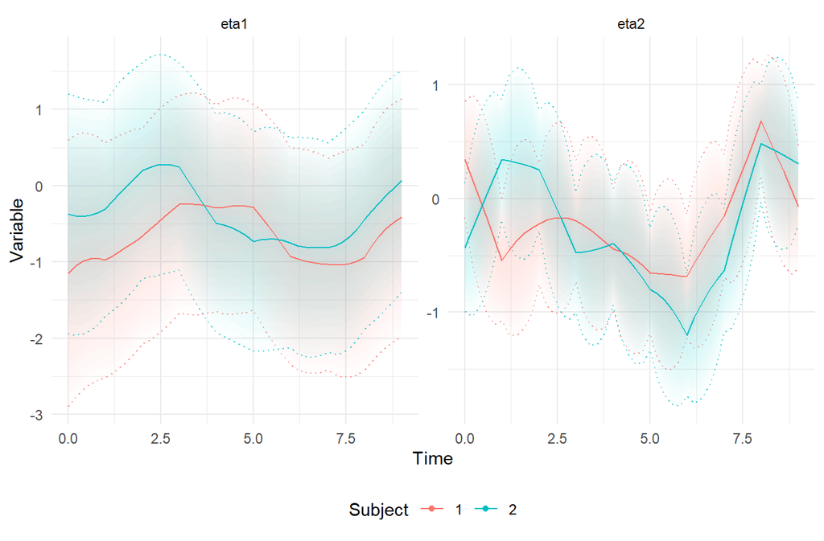

```r
plot(ctKalman(f2, subjects = 1:2, timestep = .2), kalmanvec = 'etasmooth')
```

# State-dependent measurement

A `LAMBDA` or `MANIFESTVAR` cell need not be constant. Writing a latent process name into the cell makes it an expression evaluated at the current state, so an instrument can become more or less sensitive, or noisier, as the process changes.

Free parameters used inside such an expression must be in the `PARS` matrix, because ctsem looks up the names in an expression among the `PARS` entries. `PARS` entries are unbounded and not transformed, so the residual below is written as `exp(...)` to keep the standard deviation positive.

Data in which the second indicator’s loading rises with the process, and so does the first indicator’s residual standard deviation:

```r
set.seed(9)
gensd <- ctModel(type = 'ct', n.latent = 1, n.manifest = 2,
  manifestNames = c('y1', 'y2'), latentNames = 'eta1',
  LAMBDA = matrix(c(1, '0.9 + 0.35 * eta1'), 2, 1),
  MANIFESTVAR = matrix(c('exp(-0.7 + 0.3 * eta1)', 0,
    0, 0.8), 2, 2),
  DRIFT = matrix(-0.4), DIFFUSION = matrix(1.5), T0VAR = matrix(1.7),
  T0MEANS = matrix(0), CINT = matrix(0),
  MANIFESTMEANS = matrix(c(0, 0.5), 2, 1), Tpoints = 10)

dsd <- data.frame(ctGenerate(gensd, n = 60, Tpoints = 10,
  backend = 'julia'))
head(dsd, 3)
```

```
#>   id time        y1         y2
#> 1  1    0 -1.617416  0.1401635
#> 2  1    1 -1.797942 -0.4742866
#> 3  1    2 -1.316891 -0.6378433
```

The estimation model uses the same two expressions, with parameter names in place of the generating constants:

```r
msd <- ctModel(type = 'ct', n.latent = 1, n.manifest = 2,
  manifestNames = c('y1', 'y2'), latentNames = 'eta1',
  LAMBDA = matrix(c(1, 'lam0 + lamslope * eta1'), 2, 1),
  MANIFESTVAR = matrix(c('exp(logsd0 + logsdslope * eta1)', 0,
    0, 'mvar_y2'), 2, 2),
  MANIFESTMEANS = matrix(c(0, 'mm_y2'), 2, 1),
  CINT = matrix(0), T0MEANS = matrix(0),
  PARS = matrix(c('lam0', 'lamslope', 'logsd0', 'logsdslope'), 4, 1))
msd$pars$indvarying <- FALSE

fsd <- ctFit(dsd, msd, backend = 'julia', cores = 2)
summary(fsd)$popmeans
```

```
#>              mean    sd  2.5%   50% 97.5%   mode
#> drift_eta1 -0.446    NA    NA    NA    NA -0.443
#> diff_eta1   1.418    NA    NA    NA    NA  1.413
#> mvar_y2     0.779 0.043 0.698 0.777 0.865  0.777
#> mm_y2       0.636 0.051 0.536 0.635 0.735  0.633
#> T0var_eta1  1.816 0.176 1.506 1.806 2.182  1.810
#> lam0        0.829    NA    NA    NA    NA  0.829
#> lamslope    0.321    NA    NA    NA    NA  0.323
#> logsd0     -0.376    NA    NA    NA    NA -0.375
#> logsdslope  0.194    NA    NA    NA    NA  0.195
```

Against the generating values:

```r
psd <- summary(fsd)$popmeans
sdpars <- c('lam0', 'lamslope', 'logsd0', 'logsdslope')
data.frame(
  parameter = sdpars,
  meaning = c('loading on y2 at eta1 = 0',
    'change in that loading per unit of eta1',
    'log residual sd of y1 at eta1 = 0',
    'change in that log sd per unit of eta1'),
  truth = c(0.9, 0.35, -0.7, 0.3),
  estimate = psd[sdpars, 'mean'],
  row.names = NULL)
```

```
#>    parameter                                 meaning truth estimate
#> 1       lam0               loading on y2 at eta1 = 0  0.90    0.829
#> 2   lamslope change in that loading per unit of eta1  0.35    0.321
#> 3     logsd0       log residual sd of y1 at eta1 = 0 -0.70   -0.376
#> 4 logsdslope  change in that log sd per unit of eta1  0.30    0.194
```

`ctModelIsNonlinear()` reports that such a model has cells that change with the state, so any summary of it is a reading at one particular state:

```r
ctModelIsNonlinear(fsd)
```

```
#> [1] TRUE
```

A state dependent model is therefore better described by curves than by single numbers. `ctStateDependencePlot()` finds the cells that change with the state, by computing every model matrix over a grid of states, and plots each of them against the process. This includes cells that depend on the state indirectly, through a `PARS` entry or a covariance built from a state dependent cell:

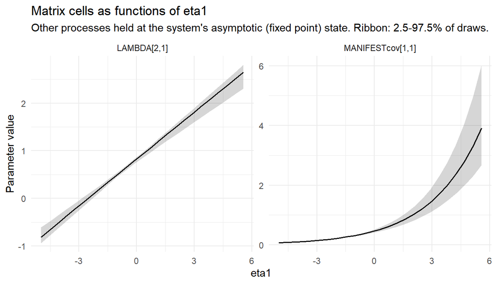

```r
ctStateDependencePlot(fsd, along = 'eta1', nsamples = 30)
```

One panel shows the loading on `y2`, rising with `eta1`. The other shows the residual *variance* of `y1` (`MANIFESTcov`, the covariance the filter uses), which rises as well. A `summary()` of this model reports one point from each of these curves.

Only `LAMBDA` and `MANIFESTVAR` depend on the state here, but `MANIFESTMEANS` can too, and on the dynamic side so can `DRIFT`, `DIFFUSION` and `CINT`.

# Summary

- `manifesttype` sets the observation model for each indicator: `0` continuous, `1` binary, `2` ordinal (with `ncategories`), `3` count, `4` censored (with `censormin` and `censormax`). Types `2` to `4` need `backend = 'julia'`.
- Continuous, count and censored indicators each have a free `MANIFESTVAR` diagonal, which is the measurement error variance, the dispersion on the log scale, and the variance inside the limits respectively. Binary and ordinal indicators have none, and `ctFit()` fixes theirs to zero.
- An ordinal indicator’s location is its `MANIFESTMEANS`, as for every other indicator. `THRESHOLDS` fixes the first threshold at zero and estimates the K-2 gaps, so a person level shift of the whole category scale is one random effect on the mean.
- Fix the latent scale once, with a fixed loading or a fixed `DIFFUSION`. With no Gaussian indicator on a process, fix the loadings.
- A count indicator’s loading sets how far its log rate moves. Keep that range moderate, because the filter’s Gaussian approximation of a Poisson update degrades once the rate varies over orders of magnitude, and the dynamic parameters are then underestimated.
- Types can be mixed, on one process or across several.
- A `LAMBDA` or `MANIFESTVAR` cell written as an expression of a latent process is evaluated at the current state. Free parameters inside it go in `PARS`, and `ctStateDependencePlot()` shows how the cell changes with the state.